# CDBN Home Field Advantage Analysis

PME

01 June, 2021, 22:48

# Overview

Results of the central dry bean nursery local adaptation and breeding strategy manuscript.

Data are from yield trials of pre-release bean lines conducted across the US and Canada.

## Setup

### Paths

```r
in_dir = 'data'  # within the R project
in_perf = 'Phenotypes_of_sequenced_individuals_home_away_analysis.csv'  # yield data
in_kin_dir = 'Kinship'  # kinship matrices, courtesy of Alice MacQueen
in_kin_pattern = c('Kinship_', '_Race.rds')


in_PC_dir = 'SVD'  # LD-adjusted genetic distance on 10 PCs, courtesy of Alice MacQueen
in_PC_pattern = c('SVD_10_PCs_', '_Race.csv')
in_locations = 'locations.rda'
in_heritability = "bean_heritability_by_year_site_race.csv" # courtesy of Mikey Kantar

out_dir = 'results'
```

### Variables

```r
# ids of columns, etc
site = 'Location_code'  # spatial environment
year = 'Year'           # temporal environment
geno = 'Taxa'           # genotype
pheno = 'SY'            # phenotype of interest = yield. Units kg/ha.
popn = 'Race'           # population
race = c('Durango', 'Mesoamerican', 'Nueva Granada')
lat = 'Latitude'
long = 'Longitue'
names(race) = race

seed = 4456  # for permutations

color_palette='FantasticFox1'

# nice names for model terms
prettynames = c(
  is_home = 'Home Site',
  Residuals = 'Residuals',
  Taxa = 'Genotype',
  Location_code = 'Site',
  Year = 'Year',
  `Year:Location_code` = 'Site-Year',
  GxE.Reduction = 'GxE.Reduction'
)
```

#### Export?

Export results to figures, rdata, etc?

```r
export = FALSE
export = TRUE
```

### Libraries and functions

```r
libs = c(
## workflow and scripting
  'here',
  'magrittr',
  'reshape2',
  'broom',
  'parallel',
## modeling
  'lme4',
  'car',
  'agricolae',
  'vegan',
## Plotting
  'wesanderson',
  'ggplot2',
  'ggpmisc',
  'gridExtra',
## tables
  'gt',
## Spatial/mapping
  'sf',
  'rnaturalearth'
)

fn_path = file.path(getwd(), 'functions')
for (i in list.files(fn_path, full.names=TRUE)) {
  source(i)
}

for (i in libs) get_libraries(i)  # install if necessary
```

### Load and munge

Main dataframe

```r
df = here(in_dir, in_perf) %>%
  read.csv(stringsAsFactors=FALSE)

# Merge the Jalisco race into Durango (which is supported by genetics)
df[, popn] %<>% gsub('Jalisco', 'Durango', .)

# Rename the Nueva Granada race to Andean
# df[, popn] %<>% gsub('Nueva Granada', 'Andean', .)

# make a numeric version of year for temporal trends.
year_num = paste(year, 'Num', sep='_')
df[, year_num] = df[, year] - max(df[, year])

# year is otherwise a factor
df[, year] %<>%
  as.numeric %>%
  factor(., levels=sort(unique(.)))

# filter siteyears
min_siteyears = 3
df %<>% filter_siteyears(site='Location_code',
                         year='Year',
                         min_times=min_siteyears)

type.convert(df) %>% summary
```

```
##  Location_code       Year                      Taxa
##  MTSI   : 802   Min.   :1981   CDBN_095_Othello  :  298
##  WYPO   : 745   1st Qu.:1989   CDBN_314_UI59     :  257
##  COFC   : 677   Median :1995   CDBN_146_Fleetwood:  254
##  MISA   : 671   Mean   :1995   CDBN_311_UI114    :  252
##  IDKI   : 661   3rd Qu.:2001   CDBN_274_Viva     :  249
##  WAOT   : 658   Max.   :2015   CDBN_171_CELRK    :  239
##  (Other):8966                  (Other)           :11631
##       CDBN_ID           Seq_ID                 Race            SY
##  Othello  :  298   CDBN_095:  298   Durango      :6428   Min.   :   0
##  UI59     :  257   CDBN_314:  257   Mesoamerican :4205   1st Qu.:1884
##  Fleetwood:  254   CDBN_146:  254   Nueva Granada:2547   Median :2567
##  UI114    :  252   CDBN_311:  252                        Mean   :2539
##  Viva     :  249   CDBN_274:  249                        3rd Qu.:3214
##  CELRK    :  239   CDBN_171:  239                        Max.   :5624
##  (Other)  :11631   (Other) :11631
##     Year_Num
##  Min.   :-34.00
##  1st Qu.:-26.00
##  Median :-20.00
##  Mean   :-19.64
##  3rd Qu.:-14.00
##  Max.   :  0.00
##
```

Heritability data from Mikey

```r
H = here(out_dir, in_heritability) %>%
  read.csv(stringsAsFactors=FALSE)
colnames(H) %<>% gsub('Site', site, .)

type.convert(H) %>% summary
```

```
##  Location_code             Race         Latitude       Longitude
##  ABBI   :  93   Durango      :2201   Min.   :18.46   Min.   :-122.65
##  ABBR   :  93   Mesoamerican :2201   1st Qu.:38.94   1st Qu.:-111.85
##  ABLE   :  93   Nueva Granada:2201   Median :43.03   Median :-103.81
##  ABVA   :  93                        Mean   :42.02   Mean   :-102.86
##  AZBO   :  93                        3rd Qu.:46.79   3rd Qu.: -96.43
##  AZHE   :  93                        Max.   :52.13   Max.   : -67.05
##  (Other):6045
##       Year       Heritability
##  Min.   :1983   Min.   :0.000
##  1st Qu.:1990   1st Qu.:0.033
##  Median :1998   Median :0.297
##  Mean   :1998   Mean   :0.329
##  3rd Qu.:2006   3rd Qu.:0.553
##  Max.   :2013   Max.   :1.000
##                 NA's   :4752
```

Locations

```r
load(here(in_dir, in_locations), verbose=TRUE)
```

```
## Loading objects:
##   locations
```

```r
head(locations)
```

| Location_code | State | Latitude | Longitue | Elevation | Location |
| --- | --- | --- | --- | --- | --- |
| ABBI | AB | 49.73000 | -111.4543 | 820 | Bow Island |
| ABBR | AB | 50.54951 | -111.8521 | 750 | Brooks |
| ABLE | AB | 49.69886 | -112.7636 | 910 | Lethbridge |
| ABVA | AB | 50.05286 | -112.1266 | 780 | Vauxhall |
| AZBO | AZ | 32.45119 | -109.9586 | 1300 | Bonita |
| AZHE | AZ | 31.43833 | -110.1081 | 1270 | Hereford |

Colors

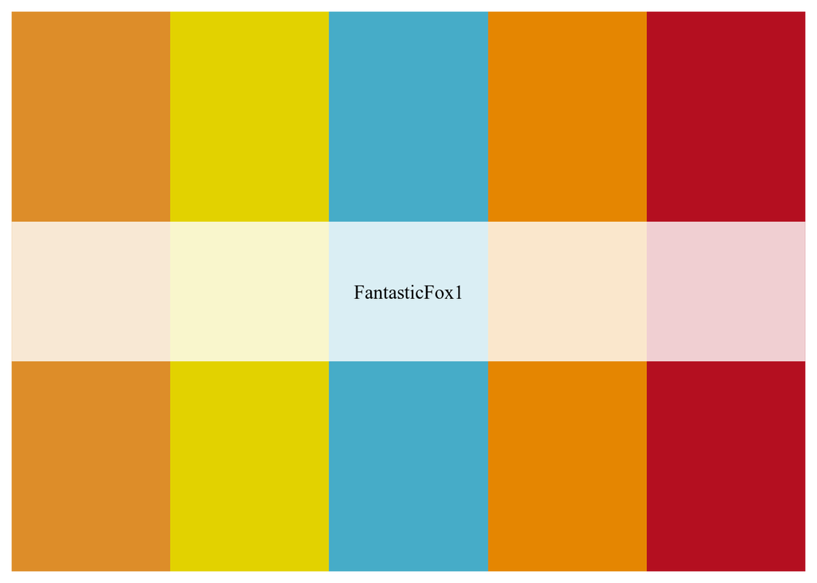

```r
colors = wes_palette(color_palette)
colors
```

### Notebook Functions

```r
# Pretty print values
pp = function(x, digits=3, decimals=2) {
  sprinter = paste('%.', decimals, 'f', sep='')
  value = signif(x, digits)
  out = sprintf(sprinter, value)
  return(out)
}

# Standard Error
se = function(x) sd(x) / sqrt(length(x))

# tidy a linear model
statsum = function(x, coef, stat=c('est', 'se', 'tstat', 'pval')) {
  out = x[x$term==coef, ]
  stat = switch(stat,
                'est' = out[, 'estimate'],
                'se' = out[, 'std.error'],
                'tstat' = out[, 'statistic'],
                'pval' = out[, 'p.value'])
  return(out)
}

# munge an anova table
get_ss = function(model) {
  a = model
  out = data.frame(
    Predictor = rownames(a),
    `Sum Squared` = a$`Sum Sq`,
    `Proportion of Variance` = round(a$`Sum Sq` / sum(a$`Sum Sq`) *100, 2),
    df = a$Df,
    `F Statistic` = round(a$`F value`, 4),
    `p Value` = signif(a$`Pr(>F)`, 3)
  )
  return(out)
}
gg_themer = function(x, remove_strip=FALSE) {

  out = x +
  theme_minimal() +
  theme(panel.grid=element_blank(),
        axis.ticks=element_line(color='gray',
                                size=0.2),
        axis.title=element_text(size=9))

  if (remove_strip) {  # for the bottom panel of fully faceted figures
    out = out + theme(strip.text=element_blank())
  }
  return(out)
}

gg_mapthemer = function(x) {
  out = x +
    theme_minimal() +
    theme(axis.ticks=element_line(color='gray',
                              size=0.2),
      axis.title=element_text(size=9),
      legend.title=element_text(size=9),
      panel.grid=element_line(color='gray',
                              size=0.2),
      legend.position='bottom')
  return(out)
}
```

# Yield

We begin the analysis by setting the context: The spatial and temporal variation of yield.

## FIGURE 1: Yield ~ Location

This will make the maps in Figure 1. Calculate average yield at each site by population

```r
mean_yields = paste(pheno, '~', site, '+', popn) %>%
  formula %>%
  aggregate(data=df, mean)
```

Load the site location data and merge with mean yields

```r
wgs84 = st_crs("+proj=longlat +ellps=WGS84")
equal_area = st_crs("+init=epsg:2163")

keep_sites = locations[, site] %>%
  sapply(function(x) x %in% df[, site])
site_map = locations %>%
  .[keep_sites, ] %>%
  st_as_sf(coords=c(long, lat),
           crs=wgs84) %>%
  st_transform(equal_area)

site_map %<>% merge(mean_yields, by=site)
```

Make a baselayer

```r
site_box = st_transform(site_map, equal_area) %>%
  st_union%>%
  st_convex_hull %>%
  st_buffer(dist=800000) %>%
  st_bbox

# rnaturalearth basemap
basemap = ne_countries(country=c('Canada', 'United States of America', 'Mexico'),
                       scale='medium',
                       returnclass='sf') %>%
  st_transform(equal_area) %>%
  st_crop(site_box)
```

### Plot

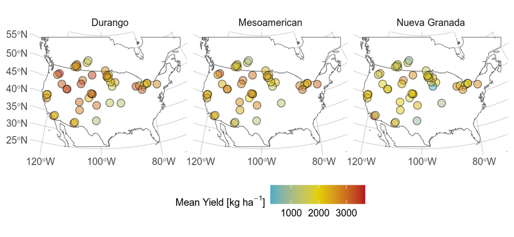

```r
site_plot = ggplot(basemap) +
  facet_wrap(paste('~', popn) %>% formula,
             nrow=1) +
  scale_fill_gradientn(colors=colors[c(3,2,5)],
                       limits=range(data.frame(site_map)[, pheno])) +
  geom_sf(fill='white',
          size=0.2) +
  geom_sf(data=site_map,
          aes_string(fill=pheno),
          shape=21,
          size=3,
          alpha=0.5,
          color='black') +
  theme_minimal() +
  labs(fill=expression(paste('Mean Yield [kg ', 'ha'^-1, ']')),
       parse=TRUE) +
  theme(axis.ticks=element_line(color='gray',
                                size=0.2),
        axis.title=element_text(size=9),
        legend.title=element_text(size=9),
        panel.grid=element_line(color='gray',
                                size=0.2),
        legend.position='bottom')
site_plot
```

### Export

```r
if (export) {
  out = "Figure 1 - Yield by Site.jpg" %>%
    here('results', .)
  jpeg(out, width=6.5, height=3, units='in', res=300)
  grid.arrange(site_plot)
  dev.off()

  # save points data
  here('results', 'figure data', 'Figure 1 - Yield by Site.gpkg') %>%
    st_write(site_map, ., delete_layer=export)
  # save basemap
  here('results', 'figure data', 'CDBN Basemap.gpkg') %>%
    st_write(basemap, ., delete_layer=export)
}
```

```
## Deleting layer `Figure 1 - Yield by Site' using driver `GPKG'
## Writing layer `Figure 1 - Yield by Site' to data source `/home/patrick/Cloud/Side Projects/cdbn-home-away/results/figure data/Figure 1 - Yield by Site.gpkg' using driver `GPKG'
## Writing 136 features with 6 fields and geometry type Point.
## Deleting layer `CDBN Basemap' using driver `GPKG'
## Writing layer `CDBN Basemap' to data source `/home/patrick/Cloud/Side Projects/cdbn-home-away/results/figure data/CDBN Basemap.gpkg' using driver `GPKG'
## Writing 3 features with 63 fields and geometry type Multi Polygon.
```

We next assessed overall yield performance and performance gains by each race across the study period.

## TABLE S1: ANOVA Yield ~ Time

The model is:

```r
# output strucure
pheno_trend = list(form=NULL,
                   model=NULL,
                   anova=NULL,
                   plot=NULL)

# formula
pheno_trend$form = paste(pheno, '~', year_num, '*', popn) %T>% print
```

```
## [1] "SY ~ Year_Num * Race"
```

Run this model

```r
pheno_trend$model = pheno_trend$form %>%
  formula %>%
  lm(data=df)

# fitted and residual values
pheno_trend$fr = data.frame(
  df[, c(year, popn)],
  fitted = fitted(pheno_trend$model),
  resid = residuals(pheno_trend$model)
)

pheno_trend$anova = Anova(pheno_trend$model)

pheno_trend$anova
```

|  | Sum Sq | Df | F value | Pr(>F) |
| --- | --- | --- | --- | --- |
| Year_Num | 252537930 | 1 | 292.697385 | 6.447198e-65 |
| Race | 1049601258 | 2 | 608.256240 | 2.147301e-253 |
| Year_Num:Race | 6894657 | 2 | 3.995535 | 1.841991e-02 |
| Residuals | 11366465372 | 13174 | NA | NA |

Each race had a different expected yield.

```r
pheno_trend$model %>% summary
```

```
##
## Call:
## lm(formula = ., data = df)
##
## Residuals:
##     Min      1Q  Median      3Q     Max
## -2800.7  -611.4    38.1   636.2  2956.9
##
## Coefficients:
##                            Estimate Std. Error t value Pr(>|t|)
## (Intercept)                3064.841     26.960 113.682  < 2e-16 ***
## Year_Num                     13.935      1.244  11.198  < 2e-16 ***
## RaceMesoamerican           -213.754     49.259  -4.339 1.44e-05 ***
## RaceNueva Granada          -696.698     50.641 -13.758  < 2e-16 ***
## Year_Num:RaceMesoamerican     6.378      2.259   2.823  0.00476 **
## Year_Num:RaceNueva Granada    2.260      2.445   0.924  0.35543
## ---
## Signif. codes:  0 '***' 0.001 '**' 0.01 '*' 0.05 '.' 0.1 ' ' 1
##
## Residual standard error: 928.9 on 13174 degrees of freedom
## Multiple R-squared:  0.101,  Adjusted R-squared:  0.1007
## F-statistic:   296 on 5 and 13174 DF,  p-value: < 2.2e-16
```

Durango yielded best. All races’ yields increased, but Mesoamerican yields increased fastest.

### Draw Table

Make this a nice table.

```r
tabs1 = pheno_trend$anova
rownames(tabs1) %<>%
  gsub('_Num', '', .) %>%
  gsub('\\:', '*', .)
tabs1 %<>%
  data.frame(X = rownames(.),
             .) %>%
  set_colnames(c(' ', colnames(tabs1))) %>%
  gt %>%
  fmt_number(columns=c('Sum Sq'), n_sigfig=4) %>%
  fmt_number(columns='F value', decimals=2) %>%
  fmt_number(columns='Pr(>F)', decimals=3) %>%
  fmt_missing(columns=c(4, 5), missing_text='-') %>%
  tab_header('Table S1',
             subtitle='ANOVA of Yield Across Time') %>%
  opt_align_table_header(align='left') %>%
  cols_align('right',
             columns=1)

tabs1
```

Table S1

ANOVA of Yield Across Time

|  | Sum Sq | Df | F value | Pr(>F) |
| --- | --- | --- | --- | --- |
| Year | 252,500,000 | 1 | 292.70 | 0.000 |
| Race | 1,050,000,000 | 2 | 608.26 | 0.000 |
| Year*Race | 6,895,000 | 2 | 4.00 | 0.018 |
| Residuals | 11,370,000,000 | 13174 | - | - |

### Export

```r
if (export) {
  out = pheno_trend$anova %>%
    signif(4)
  "Table S1 - Yield Trends ANOVA.csv" %>%
    here(out_dir, .) %>%
    write.csv(out, .)

  "Table S1 - Yield Trends ANOVA.html" %>%
    here(out_dir, .) %>%
    gtsave(tabs1, .)
}
```

##ESTIMATES: Yield ~ Race

```r
# anova values
pta = list(intercept = pheno_trend$anova[popn, ],
           slope = pheno_trend$anova[paste(year_num, popn, sep=':'), ],
           resid = pheno_trend$anova['Residuals', ]) %>%
  lapply(set_names, c('ss', 'df', 'f', 'p'))

ptl = summary(pheno_trend$model)


main_effects =
  paste(pheno, '~ 0 + ', year_num, '*', popn) %>%
  formula %>%
  lm(data=df)

tidy(main_effects)
```

| term | estimate | std.error | statistic | p.value |
| --- | --- | --- | --- | --- |
| Year_Num | 13.934591 | 1.244376 | 11.1980553 | 5.632918e-29 |
| RaceDurango | 3064.840753 | 26.959831 | 113.6817513 | 0.000000e+00 |
| RaceMesoamerican | 2851.087135 | 41.226007 | 69.1574894 | 0.000000e+00 |
| RaceNueva Granada | 2368.142901 | 42.867812 | 55.2429149 | 0.000000e+00 |
| Year_Num:RaceMesoamerican | 6.377662 | 2.258801 | 2.8234718 | 4.757787e-03 |
| Year_Num:RaceNueva Granada | 2.259751 | 2.445223 | 0.9241492 | 3.554255e-01 |

```r
HSD.test(main_effects, 'Race') %>% print
```

```
## $statistics
##    MSerror    Df     Mean       CV
##   862795.3 13174 2538.606 36.58968
##
## $parameters
##    test name.t ntr StudentizedRange alpha
##   Tukey   Race   3         3.314869  0.05
##
## $means
##                     SY      std    r   Min     Max      Q25     Q50
## Durango       2792.240 975.1819 6428  0.00 5623.52 2184.000 2827.44
## Mesoamerican  2434.553 912.6763 4205  4.48 5554.08 1833.440 2471.84
## Nueva Granada 2070.280 888.9901 2547 21.28 4735.36 1434.957 2050.72
##                   Q75
## Durango       3449.60
## Mesoamerican  3039.68
## Nueva Granada 2676.80
##
## $comparison
## NULL
##
## $groups
##                     SY groups
## Durango       2792.240      a
## Mesoamerican  2434.553      b
## Nueva Granada 2070.280      c
##
## attr(,"class")
## [1] "group"
```

## ESTIMATES: Yield ~ Time | Race

```r
get_mod = function(x) {
  out = paste(pheno, year_num, sep='~') %>%
    formula %>%
    lm(data=x) %>%
    tidy
  return(out)
}
interxn = lapply(race, function(x) {
  ss = df[df[, popn] == x, ]
  out = data.frame(popn=x,
                   get_mod(ss)
  )
  return(out)
}) %>%
  do.call(rbind, .) %>%
  set_rownames(NULL)

interxn[, sapply(interxn, is.numeric)] %<>% signif(4)

interxn
```

| popn | term | estimate | std.error | statistic | p.value |
| --- | --- | --- | --- | --- | --- |
| Durango | (Intercept) | 3065.00 | 28.050 | 109.200 | 0.000e+00 |
| Durango | Year_Num | 13.93 | 1.295 | 10.760 | 8.879e-27 |
| Mesoamerican | (Intercept) | 2851.00 | 39.930 | 71.400 | 0.000e+00 |
| Mesoamerican | Year_Num | 20.31 | 1.826 | 11.130 | 2.348e-28 |
| Nueva Granada | (Intercept) | 2368.00 | 40.510 | 58.460 | 0.000e+00 |
| Nueva Granada | Year_Num | 16.19 | 1.989 | 8.141 | 6.062e-16 |

Durango lines yielded the most at the end of the study period. Nueva Granada lines yielded the least. Mesoamerican yields grew fastest.

### FIGURE 2a: Yield ~ Time | Race

```r
se_high = function(x) mean(x) + se(x)
se_low = function(x) mean(x) - se(x)
cat_to_num = function(x) as.numeric(as.character(x))

df_2a = df[, c(year, pheno, popn)]
df_2a[, year] %<>% cat_to_num
df_2a[, 'Year0'] = df_2a[, year] - min(df_2a[, year]) # set 1980 as year zero.

yield_yr = ggplot(df_2a,
                  aes_string(x='Year0',
                             y=pheno,
                             color=popn,
                             fill=popn,
                             grp.label=popn)) +
  facet_wrap(paste('~', popn) %>% formula,
             nrow=1) +
  scale_x_continuous(breaks=seq(0, 35, by=10),
                     labels=seq(1980, 2015, by=10)) +
  scale_color_manual(values=colors, guide=NULL) +
  scale_fill_manual(values=colors, guide=NULL) +
  stat_summary(fun=mean,
               fun.max=se_high,
               fun.min=se_low,
               shape=20,
               size=0.2) +
  geom_smooth(method='lm',
              formula=y~x,
              alpha=0.1,
              size=0.2,
              fullrange=TRUE,
              level=0.95) +
  stat_poly_eq(
    aes(label=paste('list(',
                    stat(eq.label),
                    ',italic(p) < 0.001)',
                    sep="")),
    formula=y~x,
    parse=TRUE,
    label.y.npc=0.9,
    size=3,
    color='black'
  ) +
  labs(x = 'Year',
       y = 'Yield [kg/ha]',
       color=NULL,
       fill=NULL) +
  theme_minimal() +
  theme(panel.grid=element_blank(),
        axis.ticks=element_line(color='gray',
                                size=0.2),
        axis.title=element_text(size=9),
        axis.text.x=element_text(angle=90,
                                 hjust=0.5,
                                 vjust=0.5))
```

Plot this.

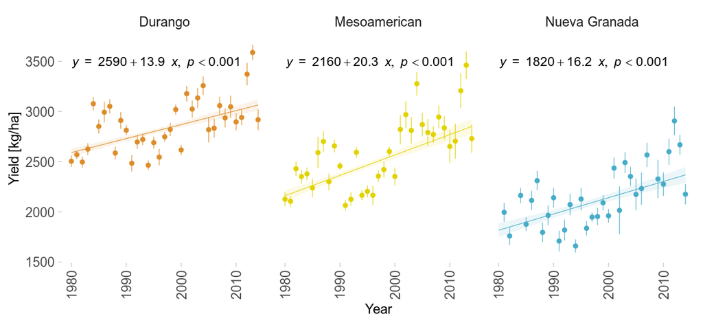

```r
yield_yr
```

#### Export Data

```r
if (export) {
  here('results', 'figure data', 'Fig 2a - yield by year.csv') %>%
    write.csv(df_2a, ., row.names=FALSE)
}
```

# Home Field Advantage

## Select genetic distance PCs

To test whether home field advantage is partially determined by genetics, we need to identify how to incorporate genetic info. The PCs are produced by the package, `bigsnpr`. This package corrects for short- and long-distance linkage disequilibrium, and returns 10 PCs by default. The PCs are primary coordinates, so distances are preserved.

While this isn’t all of the genetic variation, it should be most of the genetic variation.

```r
PCs = lapply(race, function(x) {
  paste(in_PC_pattern[1], x, in_PC_pattern[2], sep='') %>%
    here(in_dir, in_PC_dir, .) %>%
    read.csv
})

PC_scree = sapply(PCs, function(x) {
  is_PC = grepl('PC', colnames(x))
  x = x[, is_PC]^2
  out = colSums(x)/sum(x)
  return(out)
}) %>%
  as.data.frame

PC_scree[, 'PC'] = rownames(PC_scree) %>%
  gsub('PC', '', .) %>%
  as.numeric
PC_scree %<>% melt(id.vars=c('PC'), variable.name=popn, value.name='pVar')

screeplot = ggplot(PC_scree,
                   aes_string(x='PC',
                              y='pVar',
                              fill=popn)) +
  scale_x_continuous(breaks=seq(1, 10, by=2)) +
  facet_wrap(paste('~', popn) %>% formula) +
  scale_fill_manual(values=colors, guide=NULL) +
  geom_col(position='dodge') +
  labs(x = 'Principal Coordinate Axis',
       y = 'Variance [%]',
       color=NULL,
       fill=NULL) +
  theme_minimal() +
  theme(panel.grid=element_blank(),
        panel.grid.major.y=element_line(size=0.2, color='white'),
        panel.ontop=TRUE,
        axis.ticks=element_line(color='gray',
                                size=0.2),
        strip.background=element_blank(),
        strip.text=element_blank(),
        axis.title=element_text(size=9))
```

```r
ordplots = lapply(PCs, function(x) {
  x[, c('PC1', 'PC2')]
}) %>%
  do.call(rbind, .)
ordplots[, popn] = rownames(ordplots) %>%
  strsplit('\\.') %>%
  sapply('[', 1)

ordination = ggplot(ordplots,
                    aes_string(x='PC1',
                               y='PC2',
                               color=popn)) +
  scale_color_manual(values=colors, guide=NULL) +
  coord_equal() +
  facet_wrap(paste('~', popn) %>% formula) +
  geom_hline(aes(yintercept=0),
             size=0.2,
             color='gray') +
  geom_vline(aes(xintercept=0),
             size=0.2,
             color='gray') +
  geom_point(size=0.5) +
  labs(x='PC 1',
       y='PC 2') +
  theme_minimal() +
  theme(panel.grid=element_blank(),
        axis.ticks=element_line(color='gray',
                                size=0.2),
        strip.text=element_text(size=10,
                                face='bold'),
        axis.title=element_text(size=9))
```

## FIGURE S2: PCs and Scree | Race

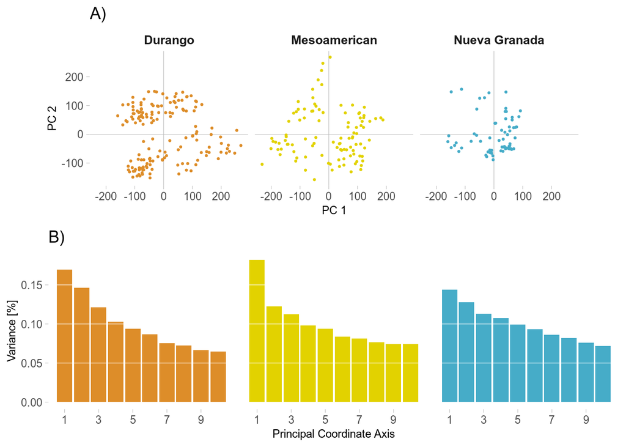

```r
grid.arrange(ordination + ggtitle('A)'),
             screeplot + ggtitle('B)'),
             nrow=2)
```

Mesoamerican lines are differentiated along PC 1, with a minor break after PC 3. Durango lines have a minor break after PC 3 with good structure along PCs 1 and 2. Andean lines aren’t horribly structured, but the break after PC2 is strongest.

### Export Figure S2

```r
p1 = ordination + ggtitle('A)')
p2 = screeplot + ggtitle('B)')

if (export) {
  out = "Figure S2 - Kinship Ordination and Scree.jpg" %>%
    here(out_dir, .)
  jpeg(out, width=6.5, height=5, units='in', res=300)
  grid.arrange(p1, p2, nrow=2)
  dev.off()

  here(out_dir, 'figure data', 'Fig S2 - ordination scree.csv') %>%
    write.csv(PC_scree, ., row.names=FALSE)
  here(out_dir, 'figure data', 'Fig S2 - ordination ax1-2 scores.csv') %>%
    write.csv(ordplots, ., row.names=FALSE)
}
```

For simplicity, we’ll take the first 3 PCs. The amount of variation these account for is:

```r
ss = subset(PC_scree, PC %in% c(1:3))
tapply(ss[, 'pVar'], ss[, popn], sum) %>%
  round(3) %>%
  multiply_by(100)
```

```
##       Durango  Mesoamerican Nueva Granada
##          43.7          41.8          38.5
```

Units are percentage points.

## FIGURE N.S.: CDBN PCs 1-2

And for completedness, to justify the analysis of these lines by race:

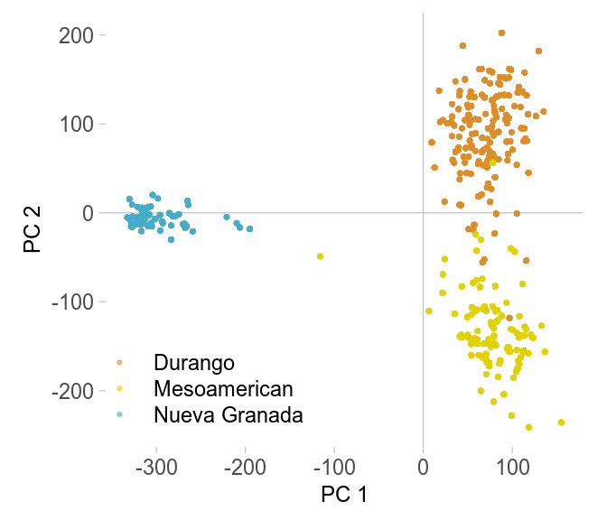

```r
full_ord = here(in_dir, in_PC_dir, paste0(in_PC_pattern[1], 'Full_CDBN.csv')) %>%
  read.csv %>%
  merge(df[, c(geno, popn)], ., by=geno)

full_ord =
  ggplot(full_ord,
         aes_string(x='PC1',
                    y='PC2',
                    color=popn)) +
  scale_color_manual(values=colors) +
  coord_equal() +
  geom_hline(aes(yintercept=0),
             size=0.2,
             color='gray') +
  geom_vline(aes(xintercept=0),
             size=0.2,
             color='gray') +
  geom_point(size=0.5,
             alpha=0.5) +
  labs(x='PC 1',
       y='PC 2',
       color=NULL) +
  theme_minimal() +
  theme(panel.grid=element_blank(),
        axis.ticks=element_line(color='gray',
                                size=0.2),
        axis.title=element_text(size=9),
        legend.position=c(0.2, 0.15),
        legend.key.height=unit(0.05, 'npc'))

full_ord
```

Andean lines are genetically distinct, and Durango and Mesoamerican are relatively distinct.

## Estimate

### ID Home Site

```r
ncpu = detectCores()
dd = mclapply(race, function(x) {
  x = df[, popn] == x
  x = df[x, ]

  x %<>% id_home(site, year, geno, pheno, blup=TRUE, verbose=FALSE)
  return(x)
  },
  mc.cores = ncpu
) %>%
  do.call(rbind, .) %>%
  set_rownames(NULL)


df = dd
```

### Models, Parameters, and Output Objects

```r
n_PC = 3

pcs = seq_len(n_PC) %>%
  paste0('PC', .) %>%
  paste(collapse=' + ')
pcs_home = seq_len(n_PC) %>%
  paste0('PC', .) %>%
  paste0('*is_home') %>%
  paste(collapse='+')


# All models
naive = paste('scale(', pheno, ') ~', year, '*', site, '+', geno)
mods = list(
  naive = naive,
  gen = gsub(geno, pcs, naive),
  home = paste(naive, '+ is_home'),
  genxhome = gsub(geno, pcs_home, naive)
) %>%
  lapply(formula) %T>%
  print
```

```
## $naive
## scale(SY) ~ Year * Location_code + Taxa
## <environment: 0x56397050a140>
##
## $gen
## scale(SY) ~ Year * Location_code + PC1 + PC2 + PC3
## <environment: 0x56397050a140>
##
## $home
## scale(SY) ~ Year * Location_code + Taxa + is_home
## <environment: 0x56397050a140>
##
## $genxhome
## scale(SY) ~ Year * Location_code + PC1 * is_home + PC2 * is_home +
##     PC3 * is_home
## <environment: 0x56397050a140>
```

```r
mod_out = list()
anova_out = list()
aic_out = list()
```

### Run

Each race will be run separately, for computational purposes.

Steps:

1. Merge dataframe subset with race kinship PCs
2. (optional) id home site
3. linear models
4. calculate variances
5. calculate AICs

This will take a long time. Cache and reload if possible.

```r
load_cache = FALSE
load_cache = TRUE
path_to_saved = here(out_dir, 'HFA_ANOVA.RData')

if (file.exists(path_to_saved) & load_cache) {
  load(path_to_saved)
} else {
  mod_out = lapply(race, function(x) {
    dd = df[, popn] == x
    dd = df[dd, ] %>%
      merge(PCs[[x]], by='Taxa')

    out = mclapply(mods, lm, data=dd, mc.cores=ncpu)
    return(out)
  })

  anova_out = lapply(mod_out, function(x) {
    mclapply(x, Anova, mc.cores=ncpu)
  })

  aic_out = lapply(mod_out, function(x) {
    sapply(x, AIC) %>%
      sort %>%
      as.matrix(ncol=1) %>%
      set_colnames('AIC')
  })

  save(anova_out, aic_out, file=path_to_saved)
}
```

### Table S2: Model Selection

Per model selection with AIC, each race had the same rank-order. The home field advantage model was most parsimonious in all cases, by quite a lot.

```r
aic_table =
  do.call(cbind, aic_out) %>%
  set_colnames(names(aic_out)) %>%
  round(0)
aic_table
```

```
##          Durango Mesoamerican Nueva Granada
## home        6772         5095          3434
## naive       7323         5421          3599
## genxhome    7662         5703          3773
## gen         8143         5997          3926
```

#### Export Table S2

```r
name_replacer=c(
  home = 'With Home Field',
  naive = 'Variety, Site, Year',
  genxhome = 'With Home Field, Kinship',
  gen = 'With Kinship'
)

tabs2 = aic_table
rownames(tabs2) %<>%
  name_replacer[.]
tabs2 %<>%
  data.frame(X = rownames(.),
             .) %>%
  set_colnames(c(' ', colnames(tabs2))) %>%
  gt %>%
  tab_header('Table S2',
             subtitle=md('AIC<sup>1</sup> of Competing Home Field Advantage Models')) %>%
  opt_align_table_header(align='left') %>%
  cols_align('right',
             columns=' ') %>%
  tab_source_note(md("<sup>1</sup>Akaike Information Criterion"))
tabs2
```

Table S2

AIC<sup>1</sup> of Competing Home Field Advantage Models

|  | Durango | Mesoamerican | Nueva Granada |
| --- | --- | --- | --- |
| With Home Field | 6772 | 5095 | 3434 |
| Variety, Site, Year | 7323 | 5421 | 3599 |
| With Home Field, Kinship | 7662 | 5703 | 3773 |
| With Kinship | 8143 | 5997 | 3926 |

<sup>1</sup>Akaike Information Criterion

```r
if (export) {
  "Table S2 - HFA Model Selection.csv" %>%
    here(out_dir, .) %>%
    write.csv(aic_table, .)

  "Table S2 - HFA Model Selection.html" %>%
    here(out_dir, .) %>%
    write.csv(tabs2, .)
}
```

We want to know how much better home is versus genxhome

```r
aic_table['home', ] - aic_table['genxhome', ]
```

```
##       Durango  Mesoamerican Nueva Granada
##          -890          -608          -339
```

### Table 2: HFA Anova

```r
min_aic = sapply(race, function(x) {
  sub_aic = aic_out[[x]]
  out = which.min(sub_aic[, 'AIC']) %>%
    rownames(sub_aic)[.]
})
anova_tables = lapply(race, function(x) {
  min_aic = min_aic[x]
  data.frame(
    popn = x,
    get_ss(anova_out[[x]][[min_aic]])
  )
}) %>%
  do.call(rbind, .) %>%
  set_rownames(NULL)

colnames(anova_tables) %<>% gsub('popn', popn, .)

anova_tables
```

| Race | Predictor | Sum.Squared | Proportion.of.Variance | df | F.Statistic | p.Value |
| --- | --- | --- | --- | --- | --- | --- |
| Durango | Year | 149.92515 | 2.43 | 34 | 28.9603 | 2.77e-169 |
| Durango | Location_code | 2044.37696 | 33.14 | 45 | 298.3708 | 0.00e+00 |
| Durango | Taxa | 206.31350 | 3.34 | 155 | 8.7419 | 5.96e-167 |
| Durango | is_home | 78.42948 | 1.27 | 1 | 515.0948 | 3.01e-109 |
| Durango | Year:Location_code | 2822.03909 | 45.74 | 459 | 40.3792 | 0.00e+00 |
| Durango | Residuals | 868.50378 | 14.08 | 5704 | NA | NA |
| Mesoamerican | Year | 114.64841 | 2.96 | 34 | 19.2015 | 6.45e-105 |
| Mesoamerican | Location_code | 1200.38456 | 30.95 | 43 | 158.9638 | 0.00e+00 |
| Mesoamerican | Taxa | 158.20517 | 4.08 | 102 | 8.8322 | 3.63e-111 |
| Mesoamerican | is_home | 50.86152 | 1.31 | 1 | 289.6247 | 1.86e-62 |

[output cut: 8 more lines]

These are all highly significant. Let’s focus on proportion of variance, and variance reduction by the HFA

```r
variance_table = sapply(race, function(x) {
  min_aic = min_aic[x]
  av = anova_out[[x]][[min_aic]] %>%
    get_ss
  out = av[, 'Proportion.of.Variance'] %>%
    set_names(av[, 'Predictor'])
})
ge_reduction = variance_table['is_home', ] %>%
  divide_by(colSums(rbind(variance_table['is_home',], variance_table['Residuals', ]))) %>%
  round(4) %>%
  multiply_by(100)
variance_table %<>% rbind(GxE.Reduction=ge_reduction)

rownames(variance_table) %<>% prettynames[.]
variance_table %<>% .[prettynames, ]

variance_table
```

```
##               Durango Mesoamerican Nueva Granada
## Home Site        1.27         1.31          1.06
## Residuals       14.08        15.80         15.63
## Genotype         3.34         4.08          3.16
## Site            33.14        30.95         28.98
## Year             2.43         2.96          2.50
## Site-Year       45.74        44.90         48.67
## GxE.Reduction    8.27         7.66          6.35
```

```r
tab2_export = data.frame(
  'X' = rownames(variance_table) %>%
    gsub('GxE.Reduction', 'Residual Reduction', .),
  variance_table/100
)
colnames(tab2_export) %<>% gsub('\\.', ' ', .)
tab2_export %<>%
  set_colnames(., gsub('X', ' ', colnames(.))) %>%
  set_rownames(NULL) %>%
  gt(rowname_col='Source') %>%
  fmt_percent(columns=colnames(variance_table), decimals=1) %>%
  tab_header(title="Table 2",
             subtitle="Partitioning of CDBN Yield Variances") %>%
  tab_spanner("Race", columns=colnames(variance_table)) %>%
  tab_footnote(footnote="Proportion of residual variance explained by home site",
               locations=cells_body(columns=1, rows=7))  %>%
  opt_align_table_header(align='left') %>%
  cols_align('right',
             columns=' ')

tab2_export
```

Table 2

Partitioning of CDBN Yield Variances

|  | Race Durango | Race Mesoamerican | Race Nueva Granada |
| --- | --- | --- | --- |
| Home Site | 1.3% | 1.3% | 1.1% |
| Residuals | 14.1% | 15.8% | 15.6% |
| Genotype | 3.3% | 4.1% | 3.2% |
| Site | 33.1% | 30.9% | 29.0% |
| Year | 2.4% | 3.0% | 2.5% |
| Site-Year | 45.7% | 44.9% | 48.7% |
| Residual Reduction<sup>1</sup> | 8.3% | 7.7% | 6.3% |

<sup>*1*</sup> Proportion of residual variance explained by home site

#### Export Table 2

```r
if (export) {
  "Table 2 - Variance Partitioning.csv" %>%
    here(out_dir, .) %>%
    write.csv(variance_table, .)

  "Table 2 - Variance Partitioning.html" %>%
    here(out_dir, .) %>%
    gtsave(tab2_export, .)
}
```

## Permute

Significance and magnitude of home field advantage is difficult to assess using regular ANOVA and linear modeling because it’s tautologically defined - we’re picking the top sites, and testing if they’re good. Really, we need to know if these top sites are better than expected based on chance. This is a permutation question

The algorithm is: 1. Permute relative yield within site-year 2. Reassign home based on relative yields 3. Calculate the coefficients for residuals ~ genotype + is_home 4. Extract the is_home coefficient 5. Compare to the observed with a two-tailed test.

For computational efficiency, we’ll also pre-partial site-year effects from the phenotype, and permute those in parallel with within-site-year relative effects. This works because these site-year effects are the same for each permutation due to permutation structure.

### Population Level

set this up to cache manually. Pretty slow.

```r
hfa_rdata = "Population_HFA_Permutation.Rdata" %>%
  here(out_dir, .)
run_permutation = !(file.exists(hfa_rdata))
# run_permutation = TRUE  # for overriding

if (run_permutation) {
  population_hfa = permute_hfa(df, level='population',
                               site, year, geno, pheno, popn,
                               times=999, seed=seed)
}
```

```r
if (run_permutation) {
  save(population_hfa, file=hfa_rdata)
} else {
  load(hfa_rdata)
}

cbind(observed = population_hfa$perms[, 1],
      expected = population_hfa$perms[, 1] - population_hfa$home_field[, 'median'],
      population_hfa$home_field)
```

```
##               observed expected    median       p05      p95 p_val
## Durango       472.7697 363.4163 109.35347  71.73526 146.1173 0.002
## Mesoamerican  453.8222 365.0937  88.72848  43.72138 134.4307 0.002
## Nueva Granada 403.3648 357.0747  46.29011 -12.35553 103.8003 0.212
```

Andean HFA was not larger than expected by chance. Durango and Mesoamerican lines both received more HFA benefit than expected.

These yield benefits in terms of percent mean yield:

```r
exp_yield = subset(interxn, term=='(Intercept)', select=c('popn', 'estimate')) %>%
  set_rownames(.[, 'popn'])
exp_yield [, 'popn'] = NULL

population_hfa$perms[, 1]/exp_yield
```

|  | estimate |
| --- | --- |
| Durango | 0.1542479 |
| Mesoamerican | 0.1591800 |
| Nueva Granada | 0.1703399 |

Yield benefits in terms of annual yield gains:

```r
yield_gain = subset(interxn,
                    term=='Year_Num',
                    select=c('popn', 'estimate')) %>%
  set_rownames(.[, 'popn'])
yield_gain[, 'popn'] = NULL

population_hfa$perms[, 1]/yield_gain
```

|  | estimate |
| --- | --- |
| Durango | 33.93896 |
| Mesoamerican | 22.34477 |
| Nueva Granada | 24.91444 |

Does this change across time?

```r
temp_hfa = temporal_hfa(df, site, year, geno, pheno, popn)
```

### Table S3: HFA ~ Time Anova

```r
temp_hfa$anova
```

|  | Sum Sq | Df | F value | Pr(>F) |
| --- | --- | --- | --- | --- |
| Year_num | 4.755246e+00 | 1 | 0.0001119074 | 0.99158205 |
| Race | 3.628888e+04 | 2 | 0.4270014320 | 0.65372179 |
| Year_num:Race | 4.100128e+05 | 2 | 4.8245101692 | 0.01012616 |
| Residuals | 3.994313e+06 | 94 | NA | NA |

Year matters for some races

```r
tabs3_data = temp_hfa$anova
rownames(tabs3_data) %<>%
  gsub('_num', '', .) %>%
  gsub('\\:', '*', .)
tabs3 = tabs3_data %<>%
  data.frame(X = rownames(.),
             .) %>%
  set_colnames(c(' ', colnames(tabs3_data))) %>%
  gt %>%
  fmt_number(columns=c('Sum Sq'), n_sigfig=4) %>%
  fmt_number(columns='F value', decimals=2) %>%
  fmt_number(columns='Pr(>F)', decimals=3) %>%
  fmt_missing(columns=c(4, 5), missing_text='-') %>%
  tab_header('Table S3',
             subtitle='ANOVA of Home Field Advantage Across Time') %>%
  opt_align_table_header(align='left') %>%
  cols_align('right',
             columns=' ')

tabs3
```

Table S3

ANOVA of Home Field Advantage Across Time

|  | Sum Sq | Df | F value | Pr(>F) |
| --- | --- | --- | --- | --- |
| Year | 4.755 | 1 | 0.00 | 0.992 |
| Race | 36,290 | 2 | 0.43 | 0.654 |
| Year*Race | 410,000 | 2 | 4.82 | 0.010 |
| Residuals | 3,994,000 | 94 | - | - |

#### Export Table S3

```r
if (export) {
  "Table S3 - HFA Across Time ANOVA.csv" %>%
    here(out_dir, .) %>%
    write.csv(tabs3_data, .)

  "Table S3 - HFA Across Time ANOVA.html" %>%
    here(out_dir, .) %>%
    gtsave(tabs3, .)
}
```

```r
temp_hfa$model %>% summary
```

```
##
## Call:
## lm(formula = ., data = out)
##
## Residuals:
##     Min      1Q  Median      3Q     Max
## -511.60 -123.48  -11.37  123.58  700.88
##
## Coefficients:
##                             Estimate Std. Error t value Pr(>|t|)
## (Intercept)                -8099.192   6893.250  -1.175   0.2430
## Year_num                       4.305      3.450   1.248   0.2152
## RaceMesoamerican           25346.569   9748.528   2.600   0.0108 *
## RaceNueva Granada          -3782.626  10882.442  -0.348   0.7289
## Year_num:RaceMesoamerican    -12.707      4.879  -2.604   0.0107 *
## Year_num:RaceNueva Granada     1.886      5.444   0.346   0.7298
## ---
## Signif. codes:  0 '***' 0.001 '**' 0.01 '*' 0.05 '.' 0.1 ' ' 1
##
## Residual standard error: 206.1 on 94 degrees of freedom
## Multiple R-squared:  0.1005, Adjusted R-squared:  0.05267
## F-statistic: 2.101 on 5 and 94 DF,  p-value: 0.07205
```

Specifically, Mesoamerican HFA decreases over time. Durango isn’t separable from Andean, though it might change independently.

### Figure 2b: HFA ~ Time | Race

First generate the supplementary datasets

```r
thfa_df = temp_hfa$temporal_hfa
# format x axis
year_num = paste0(year, '_num')
year_num0 = gsub('num', 'num0', year_num)

thfa_df[, year_num0] = thfa_df[, year_num] - min(thfa_df[, year_num])

xstep = 10
xrange = thfa_df[, year_num] %>%
  range
xmin = xrange[1] %>%
  divide_by(xstep) %>%
  floor %>%
  multiply_by(xstep)
xmax = xrange[2]
xbreaks = seq(xmin, xmax, by=xstep)
xbreaks_minor = xbreaks + (xstep/2)

# generate formula annotations for each model
ff = temp_hfa$formulas$anova %>%
  gsub('\\*', '', .) %>%
  gsub(popn, '', .) %>%
  gsub(year_num, year_num0, .) %>%
  formula
annotate = split(thfa_df, thfa_df[, popn]) %>%
  sapply(function(x) {
    mod = lm(ff, data=x) %>%
      summary %>%
      coef
    p_val = mod[2, 4]
    if (p_val <= 0.05) {
      f1 = paste('italic(y)==',
                 signif(mod[1, 1], 3), '~+~',
                 signif(mod[2, 1], 3), '~italic(x)',
                 sep='')
      f2 = ifelse(p_val < 0.001,
                  'italic(p)~<~0.001',
                  paste('italic(p)==', signif(p_val, 1)))
      out = paste('list(', f1, ',', f2, ')', sep='')
    } else {
      out = 'n.s.'
    }
    return(out)
  })
annotate =
  data.frame(popn = names(annotate),
             text = annotate,
             x = 1980,
             y = 1300)
names(annotate) %<>%
  gsub('popn', popn, .)

# generate ribbons for expected values
exp_hfa = population_hfa$perms %>%
  .[, -c(1)] %>%
  apply(1, function(x) {
    c(p50 = median(x),
      p05 = quantile(x, 0.05) %>% set_names(NULL),
      p95 = quantile(x, 0.95) %>% set_names(NULL))
  }) %>%
  t
exp_hfa %<>% data.frame(
  popn = rownames(.),
  .
) %>%
  set_rownames(NULL) %>%
  rbind(., .)
exp_hfa$x_val = c(
  rep(xrange[1], nrow(exp_hfa)/2),
  rep(xrange[2], nrow(exp_hfa)/2)
)
names(exp_hfa) %<>% gsub('popn', popn, .)
```

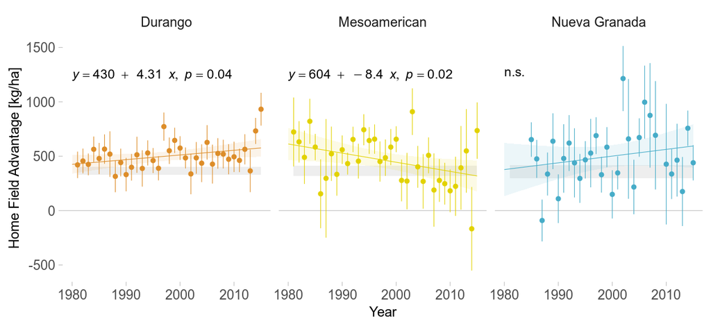

```r
thfa_df %<>% .[, c(paste0(year, '_num'),
                   paste0(year, '_num0'),
                   'Estimate', popn, 'Std.Error')]
thfa_plot = thfa_df %>%
  ggplot(aes_string(x=paste0(year, '_num'),
                    y='Estimate',
                    color=popn,
                    fill=popn,
                    grp.label=popn)) +
  facet_wrap(paste('~', popn) %>% formula,
             nrow=1) +
  scale_color_manual(values=colors, guide=NULL) +
  scale_fill_manual(values=colors, guide=NULL) +
  scale_x_continuous(breaks=xbreaks, minor_breaks=xbreaks_minor) +
  geom_hline(aes(yintercept=0),
             size=0.2,
             color='gray') +
  geom_ribbon(data=exp_hfa,
              aes_string(ymin='p05',
                         ymax='p95',
                         x='x_val'),
              fill='#EEEEEE',
              alpha=1,
              inherit.aes=FALSE) +
  geom_pointrange(aes(ymin=Estimate - Std.Error,
                      ymax=Estimate + Std.Error),
                  shape=20,
                  size=0.2) +
  geom_smooth(method='lm',
              formula=y~x,
              alpha=0.1,
              size=0.2,
              level=0.95,
              fullrange=TRUE) +
  geom_text(data=annotate,
            aes(x=x,
                y=y,
                label=text),
            color='black',
            hjust='inward',
            vjust='inward',
            parse=TRUE,
            size=3) +
  labs(x='Year',
       y='Home Field Advantage [kg/ha]',
       color=NULL) +
  theme_minimal() +
  theme(panel.grid=element_blank(),
        axis.title=element_text(size=9),
        axis.ticks=element_line(color='gray',
                                size=0.2))
thfa_plot
```

```r
split(thfa_df, thfa_df[, popn]) %>%
  lapply(function(x) {
    mod = lm(ff, data=x) %>%
      summary %>%
      coef
    mod})
```

```
## $Durango
##               Estimate Std. Error   t value     Pr(>|t|)
## (Intercept) 429.582072  40.067541 10.721448 2.749856e-12
## Year_num0     4.305287   2.026303  2.124701 4.118954e-02
##
## $Mesoamerican
##               Estimate Std. Error   t value     Pr(>|t|)
## (Intercept) 604.033360  69.867410  8.645424 5.426432e-10
## Year_num0    -8.401486   3.533347 -2.377770 2.336570e-02
##
## $`Nueva Granada`
##              Estimate Std. Error  t value    Pr(>|t|)
## (Intercept) 383.28606 114.276967 3.354010 0.002299202
## Year_num0     6.19137   5.513704 1.122906 0.271013996
```

#### Export Data

```r
if (export) {
  here(out_dir, 'figure data', 'Fig 2b - HFA across time.csv') %>%
    write.csv(thfa_df, ., row.names=FALSE)

  here(out_dir, 'figure data', 'Fig 2b - HFA across time Annotations.csv') %>%
    write.csv(annotate, ., row.names=FALSE)

  here(out_dir, 'figure data', 'Fig 2b - HFA across time Expectation.csv') %>%
    write.csv(exp_hfa, ., row.names=FALSE)
}
```

# Figure 2 Combined

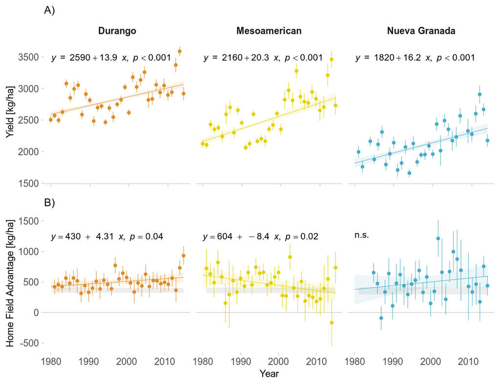

```r
fig2a = yield_yr +
  ggtitle('A)') +
  theme(axis.text.x = element_blank(),
        axis.title.x = element_blank(),
        axis.line.x=element_line(size=0.2, color='gray'),
        plot.title=element_text(size=10),
        strip.text=element_text(face='bold'))
fig2b = thfa_plot +
  ggtitle('B)') +
  theme(strip.text=element_blank(),
        plot.title=element_text(size=10))

grid.arrange(fig2a, fig2b, nrow=2)
```

## Export Figure 2

```r
if (export) {
  out = "Figure 2 - Yield, HFA Trends.jpg" %>%
    here('results', .)
  jpeg(out, width=6.5, height=5, units='in', res=300)
  grid.arrange(fig2a, fig2b, nrow=2)
  dev.off()
}
```

# Heritability

## Trends across time

```r
herit_mod_ff = "Heritability ~ year*popn" %>%
  gsub('popn', popn, .) %>%
  gsub('year', year, .)

herit_mod = formula(herit_mod_ff) %>%
  lm(data=H)

Anova(herit_mod)
```

|  | Sum Sq | Df | F value | Pr(>F) |
| --- | --- | --- | --- | --- |
| Year | 0.5314916 | 1 | 6.911425 | 8.635775e-03 |
| Race | 0.7138204 | 2 | 4.641199 | 9.759029e-03 |
| Year:Race | 3.8927177 | 2 | 25.310112 | 1.432341e-11 |
| Residuals | 141.8813164 | 1845 | NA | NA |

```r
summary(herit_mod)
```

```
##
## Call:
## lm(formula = ., data = H)
##
## Residuals:
##      Min       1Q   Median       3Q      Max
## -0.43113 -0.25710 -0.03059  0.21717  0.70928
##
## Coefficients:
##                         Estimate Std. Error t value Pr(>|t|)
## (Intercept)            -8.883801   2.623104  -3.387 0.000722 ***
## Year                    0.004610   0.001314   3.507 0.000463 ***
## RaceMesoamerican       20.347799   3.740702   5.440 6.05e-08 ***
## RaceNueva Granada      -5.274721   3.793639  -1.390 0.164572
## Year:RaceMesoamerican  -0.010175   0.001874  -5.429 6.42e-08 ***
## Year:RaceNueva Granada  0.002641   0.001901   1.390 0.164818
## ---
## Signif. codes:  0 '***' 0.001 '**' 0.01 '*' 0.05 '.' 0.1 ' ' 1
##
## Residual standard error: 0.2773 on 1845 degrees of freedom
##   (4752 observations deleted due to missingness)
## Multiple R-squared:  0.03502,    Adjusted R-squared:  0.0324
## F-statistic: 13.39 on 5 and 1845 DF,  p-value: 7.567e-13
```

```r
# generate formula annotations for each model
ff = herit_mod_ff %>%
  gsub('\\*', '', .) %>%
  gsub(popn, '', .) %>%
  gsub(year_num, year_num0, .) %>%
  formula
annotate = split(H, H[, popn]) %>%
  sapply(function(x) {
    mod = lm(ff, data=x) %>%
      summary %>%
      coef
    p_val = mod[2, 4]
    if (p_val <= 0.05) {
      f1 = paste('italic(y)==',
                 signif(mod[1, 1], 3), '~+~',
                 signif(mod[2, 1], 3), '~italic(x)',
                 sep='')
      f2 = ifelse(p_val < 0.001,
                  'italic(p)~<~0.001',
                  paste('italic(p)==', signif(p_val, 1)))
      out = paste('list(', f1, ',', f2, ')', sep='')
    } else {
      out = 'n.s.'
    }
    return(out)
  })
annotate =
  data.frame(popn = names(annotate),
             text = annotate,
             x = 1980,
             y = 1300)
names(annotate) %<>%
  gsub('popn', popn, .)
```

### Figure 3b: Heritability ~ Year | Race

```r
se_high = function(x) mean(x) + se(x)
se_low = function(x) mean(x) - se(x)
cat_to_num = function(x) as.numeric(as.character(x))


# year zero for nice intercepts in the eqn
H[, 'Y0'] = H[, year] - min(H[, year])

H_df = H[, c(year, 'Y0', 'Heritability', popn)]

H_yr = ggplot(H_df,
              aes_string(x='Y0',
                         y='Heritability',
                         color=popn,
                         fill=popn)) +
  facet_wrap(paste('~', popn) %>% formula,
             nrow=1) +
  scale_x_continuous(limits=c(0,35),
                     breaks=seq(0, 35, by=10),
                     labels=seq(1980, 2015, by=10)) +
  scale_color_manual(values=colors, guide=NULL) +
  scale_fill_manual(values=colors, guide=NULL) +
  stat_summary(fun=mean,
               fun.max=se_high,
               fun.min=se_low,
               shape=20,
               size=0.2) +
  geom_smooth(method='lm',
              formula=y~x,
              alpha=0.1,
              size=0.2,
              fullrange=TRUE,
              level=0.95) +
  stat_poly_eq(
    aes(label=paste('list(',
                    stat(eq.label),
                    ',italic(p) < 0.001)',
                    sep="")),
    formula=y~x,
    parse=TRUE,
    label.y.npc=0.9,
    size=3,
    color='black'
  ) +
  labs(x = 'Year',
       y = 'Yield Heritability [au]',
       color=NULL,
       fill=NULL) +
  theme_minimal() +
  theme(panel.grid=element_blank(),
        axis.ticks=element_line(color='gray',
                                size=0.2),
        axis.title=element_text(size=9))
```

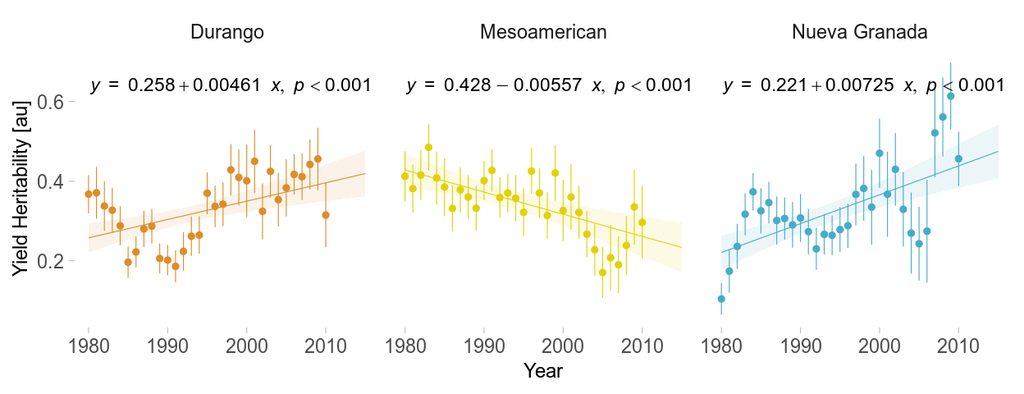

```r
H_yr
```

#### Export Figure 3b

```r
H_yr = H_yr +
  ggtitle('B)') +
  theme(plot.title=element_text(size=10))

if (export) {
  "Figure 3b - Heritability vs Time.jpg" %>%
    here(out_dir, .) %>%
    jpeg(width=6.5, height=2.5, units='in', res=300)
  grid.arrange(H_yr)
  dev.off()

  here('results', 'figure data', 'Fig 3b - heritability vs year.csv') %>%
    write.csv(H_df, ., row.names=FALSE)
}
```

## Relationship with years in dataset, site variation in heritability, race yield

### Figure S1A: sd(H2) ~ Years at each site

```r
site_years = df[, c(year, site)] %>%
  unique %>%
  na.omit %>%
  {tapply(.[, year], .[, site], length)}



sd_H = tapply(H[, 'Heritability'], H[, site], sd, na.rm=TRUE)
mean_H = tapply(H[, 'Heritability'], H[, site], mean, na.rm=TRUE)

H_stats = data.frame(site = rownames(site_years),
                     site_year = site_years,
                     sd_H = sd_H[rownames(site_years)],
                     mean_H = mean_H[rownames(site_years)])
```

```r
sd_H_mod = "sd_H ~ site_year" %>%
  formula %>%
  lm(data=H_stats)
Anova(sd_H_mod)
```

|  | Sum Sq | Df | F value | Pr(>F) |
| --- | --- | --- | --- | --- |
| site_year | 0.03248136 | 1 | 6.513051 | 0.01425714 |
| Residuals | 0.21943325 | 44 | NA | NA |

```r
summary(sd_H_mod)
```

```
##
## Call:
## lm(formula = ., data = H_stats)
##
## Residuals:
##      Min       1Q   Median       3Q      Max
## -0.17303 -0.05447 -0.00155  0.04804  0.15760
##
## Coefficients:
##             Estimate Std. Error t value Pr(>|t|)
## (Intercept) 0.212325   0.017138  12.389 6.07e-16 ***
## site_year   0.002895   0.001134   2.552   0.0143 *
## ---
## Signif. codes:  0 '***' 0.001 '**' 0.01 '*' 0.05 '.' 0.1 ' ' 1
##
## Residual standard error: 0.07062 on 44 degrees of freedom
##   (1 observation deleted due to missingness)
## Multiple R-squared:  0.1289, Adjusted R-squared:  0.1091
## F-statistic: 6.513 on 1 and 44 DF,  p-value: 0.01426
```

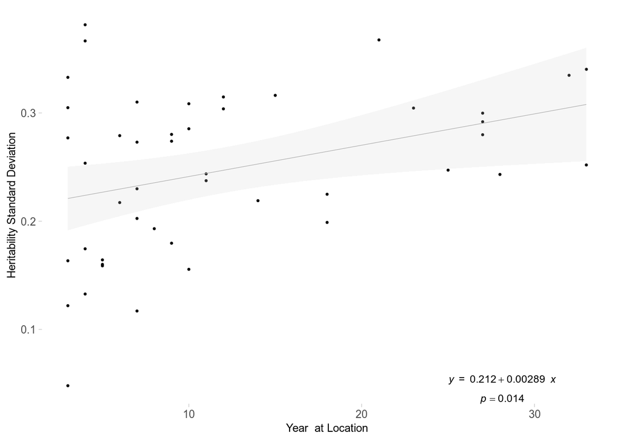

```r
p_val_sd_H = Anova(sd_H_mod)[1, 4] %>%
  signif(2)

sd_H_plt = ggplot(H_stats,
                  aes_string(x='site_year',
                             y='sd_H')) +
  geom_point(size=0.5) +
  geom_smooth(method='lm',
              formula='y~x',
              alpha=0.2,
              size=0.2,
              color='darkgray',
              fill='lightgray') +
  stat_poly_eq(
    aes(label=paste('atop(',
                    stat(eq.label),
                    ',italic(p) == ', p_val_sd_H, ')',
                    sep="")),
    formula=y~x,
    parse=TRUE,
    label.y.npc=0.0,
    label.x.npc=0.9,
    size=3,
    color='black'
  ) +
  labs(x='Year  at Location',
       y='Heritability Standard Deviation')

sd_H_plt %<>%
  gg_themer

sd_H_plt
```

### Figure S1b: H2 ~ SD(H2)

```r
mean_H_mod = "mean_H ~ sd_H" %>%
  formula %>%
  lm(data=H_stats)
```

```r
Anova(mean_H_mod)
```

|  | Sum Sq | Df | F value | Pr(>F) |
| --- | --- | --- | --- | --- |
| sd_H | 0.008281079 | 1 | 0.5731495 | 0.4530453 |
| Residuals | 0.635728467 | 44 | NA | NA |

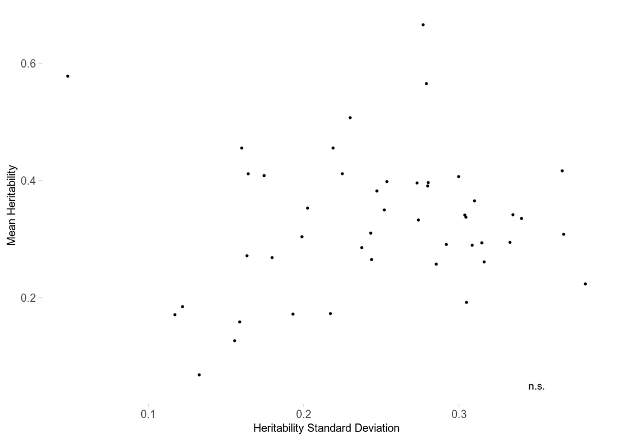

```r
label_df = data.frame(x=0.35,
                      y=0.05,
                      label='n.s.')
mean_H_plt = ggplot(H_stats,
                  aes_string(x='sd_H',
                             y='mean_H')) +
  geom_point(size=0.5) +
  geom_text(data=label_df,
            aes(x=x,
                y=y,
                label=label),
            size=3,
            color='black',
            inherit.aes=FALSE) +
  labs(x='Heritability Standard Deviation',
       y='Mean Heritability')

mean_H_plt %<>%
  gg_themer

mean_H_plt
```

### Figure S1c: yield ~ H | Race

```r
site_yield = "pheno ~ site*popn" %>%
  gsub('pheno', pheno, .) %>%
  gsub('site', site, .) %>%
  gsub('popn', popn, .) %>%
  formula %>%
  aggregate(data=df, mean)

site_H = "Heritability ~ site*popn" %>%
  gsub('site', site, .) %>%
  gsub('popn', popn, .) %>%
  formula %>%
  aggregate(data=H, mean)

yield_H = merge(site_yield, site_H, by=c(site, popn))
```

```r
yield_H_mod = "pheno ~ Heritability*popn" %>%
  gsub('pheno', pheno, .) %>%
  gsub('popn', popn, .) %>%
  formula %>%
  lm(data=yield_H)
Anova(yield_H_mod)
```

|  | Sum Sq | Df | F value | Pr(>F) |
| --- | --- | --- | --- | --- |
| Heritability | 2310675 | 1 | 6.646954 | 1.110161e-02 |
| Race | 8039230 | 2 | 11.562941 | 2.485545e-05 |
| Heritability:Race | 1169544 | 2 | 1.682172 | 1.901853e-01 |
| Residuals | 43106013 | 124 | NA | NA |

```r
yield_H_mod = "pheno ~ Heritability + popn" %>%
  gsub('pheno', pheno, .) %>%
  gsub('popn', popn, .) %>%
  formula %>%
  lm(data=yield_H)
Anova(yield_H_mod)
```

|  | Sum Sq | Df | F value | Pr(>F) |
| --- | --- | --- | --- | --- |
| Heritability | 2310675 | 1 | 6.575751 | 1.151128e-02 |
| Race | 8039230 | 2 | 11.439077 | 2.722657e-05 |
| Residuals | 44275557 | 126 | NA | NA |

```r
summary(yield_H_mod)
```

```
##
## Call:
## lm(formula = ., data = yield_H)
##
## Residuals:
##      Min       1Q   Median       3Q      Max
## -1442.97  -387.39    83.67   356.89  1538.34
##
## Coefficients:
##                   Estimate Std. Error t value Pr(>|t|)
## (Intercept)         2301.9      128.3  17.943  < 2e-16 ***
## Heritability         752.8      293.6   2.564   0.0115 *
## RaceMesoamerican    -305.9      129.6  -2.361   0.0198 *
## RaceNueva Granada   -608.7      127.3  -4.783 4.74e-06 ***
## ---
## Signif. codes:  0 '***' 0.001 '**' 0.01 '*' 0.05 '.' 0.1 ' ' 1
##
## Residual standard error: 592.8 on 126 degrees of freedom
## Multiple R-squared:  0.1976, Adjusted R-squared:  0.1784
## F-statistic: 10.34 on 3 and 126 DF,  p-value: 3.926e-06
```

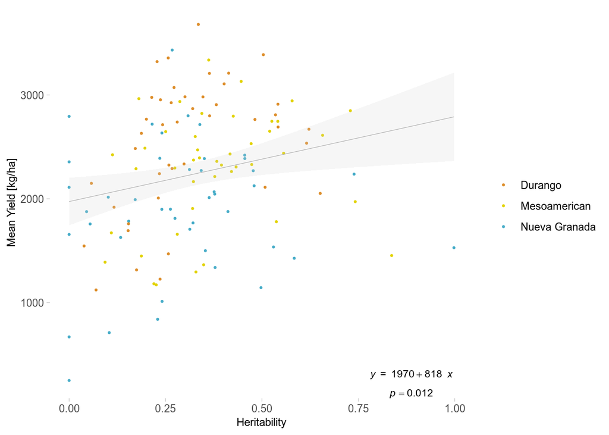

```r
p_val_yield_H = Anova(yield_H_mod)[1, 4] %>%
  signif(2)
yield_H_plt = ggplot(data=yield_H,
                     aes_string(x='Heritability',
                                y=pheno)) +
  scale_color_manual(values=colors) +
  scale_fill_manual(values=colors, guide=NULL) +
  geom_point(aes_string(color=popn),
             size=0.5) +
  geom_smooth(aes_string(x='Heritability',
                        y=pheno),
              method='lm',
              formula='y~x',
              color='darkgray',
              fill='lightgray',
              alpha=0.2,
              size=0.2) +
  stat_poly_eq(
    aes(label=paste('atop(',
                    stat(eq.label),
                    ',italic(p) == ', p_val_yield_H, ')',
                    sep="")),
    formula=y~x,
    parse=TRUE,
    label.y.npc=0,
    label.x.npc=0.95,
    size=3,
    color='black'
  ) +
  labs(x='Heritability',
       y='Mean Yield [kg/ha]',
       color=NULL)

yield_H_plt %<>% gg_themer

yield_H_plt
```

### Combine

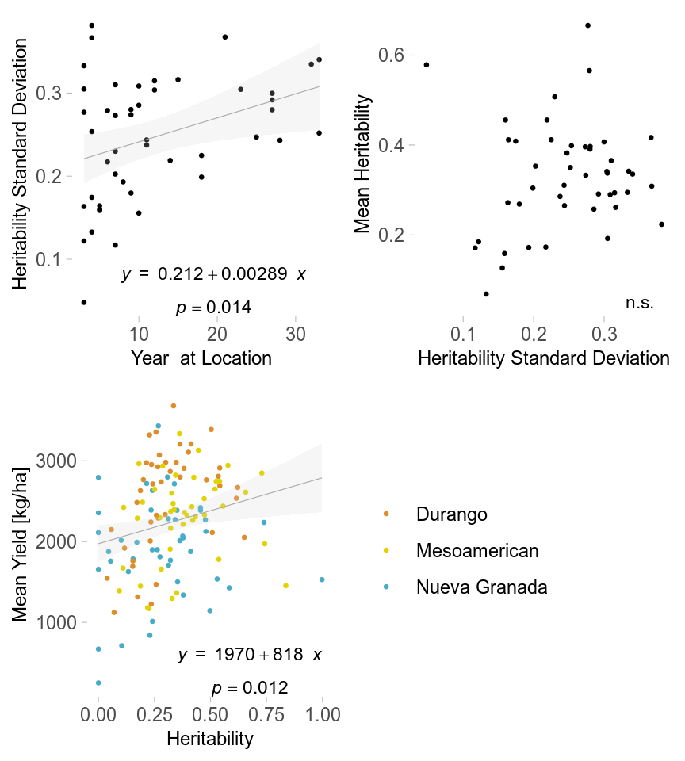

```r
grid.arrange(grobs=list(sd_H_plt, mean_H_plt, yield_H_plt),
             widths=c(1,2,2,1),
             layout_matrix=rbind(c(1,1,2,2),
                                 c(3,3,3,NA))
)
```

#### Export Figure S1

```r
if (export) {
  "Figure S1 - Heritability Statistics and Relationships.jpg" %>%
    here(out_dir, .) %>%
    jpeg(width=4.5, height=5, units='in', res=300)
  grid.arrange(grobs=list(sd_H_plt, mean_H_plt, yield_H_plt),
             widths=c(1,2,2,1),
             layout_matrix=rbind(c(1,1,2,2),
                                 c(3,3,3,NA))
  )
  dev.off()

  here(out_dir, 'figure data', 'Fig S1 - Heritability Site Statistics.csv') %>%
    write.csv(H_stats, ., row.names=FALSE)
  here(out_dir, 'figure data', 'Fig S1 - Heritability vs Yield.csv') %>%
    write.csv(yield_H, ., row.names=FALSE)
}
```

# Home Location, Heritability, and Kinship

Efficiently breeding for environmental specialization requires high yield gains from specialization, a genetic basis for specialization, and high heritability in yields.

## Home site distance vs kinship

To infer a genetic basis, we correlated genetic distance with home site distance.

Again, we’ll use the first 3 PCs.

```r
n_PC = n_PC
# defined above in
#    Home Field Advantage -> Estimate ->
#       Models, Parameters, and Output Objects.

home_site_dist = measure_home_distance(df, locations,
                                       geno, site, lat, long,
                                       great_circle=TRUE)

# reconstruct LD-corrected distance from PCs
genetic_dist = lapply(PCs, function(x) {
  rownames(x) = x[, geno]
  x[, geno] = NULL
  out = dist(x[, 1:n_PC]) %>%
    as.matrix
  return(out)
})
```

```r
# uses vegan::mantel
home_genetic_corr = lapply(genetic_dist, function(x) {
  home_dist = home_site_dist[rownames(x), colnames(x)]
  out = mantel(home_dist, x)
})

home_genetic_corr
```

```
## $Durango
##
## Mantel statistic based on Pearson's product-moment correlation
##
## Call:
## mantel(xdis = home_dist, ydis = x)
##
## Mantel statistic r: 0.1124
##       Significance: 0.001
##
## Upper quantiles of permutations (null model):
##    90%    95%  97.5%    99%
## 0.0333 0.0468 0.0584 0.0670
## Permutation: free
## Number of permutations: 999
##
##
## $Mesoamerican
##
## Mantel statistic based on Pearson's product-moment correlation
##
## Call:
## mantel(xdis = home_dist, ydis = x)
##
## Mantel statistic r: 0.06808
##       Significance: 0.024
##
## Upper quantiles of permutations (null model):
##    90%    95%  97.5%    99%
## 0.0437 0.0559 0.0668 0.0758
## Permutation: free
## Number of permutations: 999
##
##
## $`Nueva Granada`
##
## Mantel statistic based on Pearson's product-moment correlation
##
## Call:
## mantel(xdis = home_dist, ydis = x)
##
## Mantel statistic r: -0.02161
##       Significance: 0.638
##
## Upper quantiles of permutations (null model):
##    90%    95%  97.5%    99%
## 0.0673 0.0902 0.1092 0.1452
## Permutation: free
## Number of permutations: 999
```

```r
dist_to_df = function(x) {
  diag(x) = NA
  x[upper.tri(x)] = NA

  out = data.frame(A = c(row(x)),
                 B = c(col(x)),
                 distance = c(x))
  out %<>% na.omit

  out[, 'A'] %<>% rownames(x)[.]
  out[, 'B'] %<>% colnames(x)[.]
  return(out)
}

dist_df = lapply(genetic_dist, function(x) {
  home_dist = home_site_dist[rownames(x), colnames(x)] %>%
    dist_to_df %>%
    set_colnames(c('A', 'B', 'home_distance'))

  gen_dist = dist_to_df(x) %>%
    set_colnames(c('A', 'B', 'genetic_distance'))

  out = merge(home_dist, gen_dist, by=c('A', 'B'))

  return(out)
})

dist_df %<>%
  names %>%
  lapply(function(x) {
    out = data.frame(
      popn = x,
      dist_df[[x]]
    )
    names(out) %<>% gsub('popn', popn, .)
    return(out)
  }) %>%
  do.call(rbind, .)

dist_annotate =
  data.frame(popn = names(home_genetic_corr),
             signif = sapply(home_genetic_corr, '[[', 'signif'),
             corr = sapply(home_genetic_corr, '[[', 'statistic'),
             x = 0,
             y = 3800)
colnames(dist_annotate) %<>% gsub('popn', popn, .)
dist_annotate$text =
  with(dist_annotate,
       paste("list(Mantel~italic(r)==",
             round(corr, 3),
             ', italic(p)==',
             signif(signif, 2),
             ')',
             sep='')
)
is_signif = dist_annotate$signif <= 0.05
dist_annotate[!is_signif, 'text'] = 'n.s.'
```

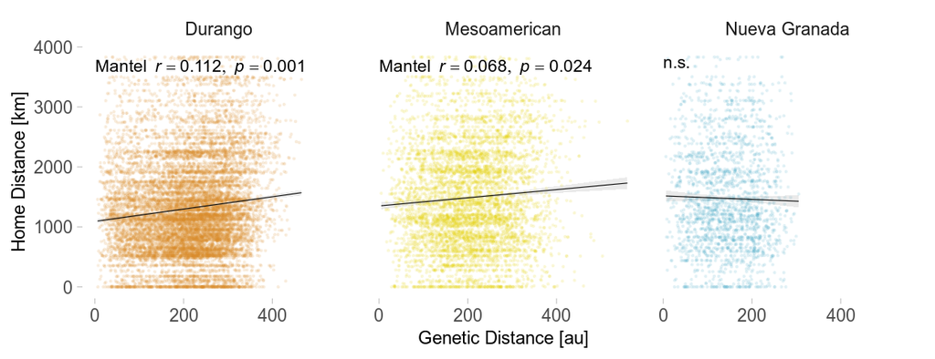

```r
home_genetic_plot = dist_df %>%
  ggplot(aes_string(x='genetic_distance',
                    y='home_distance',
                    color=popn)) +
  scale_color_manual(values=colors, guide=NULL) +
  facet_wrap(paste('~', popn) %>% formula) +
  geom_point(alpha=0.1,
             size=0.2) +
  geom_smooth(method='lm',
              formula='y~x',
              alpha=0.2,
              color='black',
              size=0.2,
              level=0.95) +
  geom_text(data=dist_annotate,
             aes(x=x,
                 y=y,
                 label=text),
            color='black',
            hjust='inward',
            vjust='inward',
             parse=TRUE,
            size=3) +
  labs(x='Genetic Distance [au]',
       y='Home Distance [km]') +
  theme_minimal() +
  theme(panel.grid=element_blank(),
        axis.ticks=element_line(color='gray',
                                size=0.2),
        axis.title=element_text(size=9))
home_genetic_plot
```

## HFA vs Heritability

HFA and heritability patterns inform breeding strategies (per Table 1)

To calculate site HFA:

1. Calculate HFA for each genotype
2. Average these HFAs by home site ID

```r
# identify HFA conferred to varieties
geno_hfa = permute_hfa(df, level='genotype', site, year, geno, pheno, popn, times=1,
                       seed=seed)

geno_hfa %<>%
  extract2('perms') %>%
  lapply(function(x) x[, 'observed']) %>%
  unlist

geno_hfa_names =
  names(geno_hfa) %>%
  strsplit('\\.') %>%
  do.call(rbind, .) %>%
  gsub(site, '', .) %>%
  set_colnames(c(popn, geno))

geno_hfa %<>% data.frame(
  geno_hfa_names,
  HFA = .
) %>%
  set_rownames(NULL)

geno_homes = subset(df, is_home, select=c(geno, popn, site)) %>%
  unique

# Calculate mean HFA by site
site_hfa = merge(geno_hfa, geno_homes, by=c(popn, geno)) %>% # merge
  {tapply(.[, 'HFA'], .[, c(site, popn)], mean)} %>%  # summarize
  melt(value.name='HFA')

# calculate
site_H = tapply(H[, 'Heritability'], H[, c(site, popn)], mean, na.rm=TRUE) %>%
  melt(value.name='H')

site_H_HFA = merge(site_hfa, site_H, by=c(site, popn))
```

### Figure 4a: HFA vs Heritability

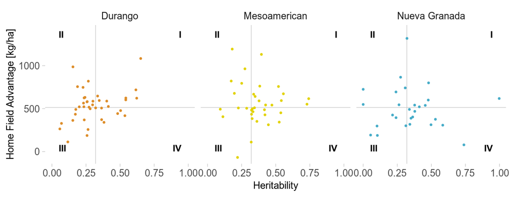

```r
annotater = data.frame(label=c('II', 'I', 'III', 'IV') %>%
                         paste('bold(', ., ')', sep=''),
                       x=c(0.05, 0.95, 0.05, 0.95),
                       y=c(1400, 1400, 0, 0))

medians=c(H = median(site_H_HFA$H, na.rm=TRUE),
          HFA = median(site_H_HFA$HFA, na.rm=TRUE))

site_hfa_plot =
  ggplot(site_H_HFA,
         aes_string(x='H',
                    y='HFA',
                    color=popn)) +
  scale_color_manual(values=colors, guide=NULL) +
  facet_wrap(paste('~', popn) %>% formula,
             nrow=1) +
  geom_vline(aes(xintercept=medians['H']),
             color='gray',
             size=0.2) +
  geom_hline(aes(yintercept=medians['HFA']),
             color='gray',
             size=0.2) +
  geom_point(size=0.5) +
  geom_text(data=annotater,
            aes(label=label,
                x=x,
                y=y),
            hjust='inward',
            vjust='inward',
            size=3,
            inherit.aes=FALSE,
            parse=TRUE) +
  theme_minimal() +
  labs(x='Heritability',
       y='Home Field Advantage [kg/ha]') +
  theme(panel.grid=element_blank(),
        axis.ticks=element_line(color='gray',
                                size=0.2),
        axis.title=element_text(size=9))
site_hfa_plot
```

We are interested in those sites in Quadrant I - the ones where heritability is high, and HFA is also high.

### Fig 4b - Sites with high H2, HFA

ID best sites

```r
best_sites = split(site_H_HFA, site_H_HFA[, popn])

best_sites %<>% lapply(function(x) {
  med_H = median(x$H, na.rm=TRUE)
  med_HFA = median(x$HFA, na.rm=TRUE)

  is_topH = x$H > med_H
  is_topHFA = x$HFA > med_HFA

  out = x[is_topH & is_topHFA, ] %>%
    na.omit
  return(out)
}) %>%
  do.call(rbind, .) %>%
  set_rownames(NULL)
```

Merge with spatial data

```r
bs_plot = site_map[, c(site, 'Location', popn)] %>%
  merge(best_sites, by=c(site, popn), all.x=TRUE)
bs_plot$plotval = 1*(!is.na(bs_plot$HFA))
```

Plot best sites for each race, single map for easy comparisons.

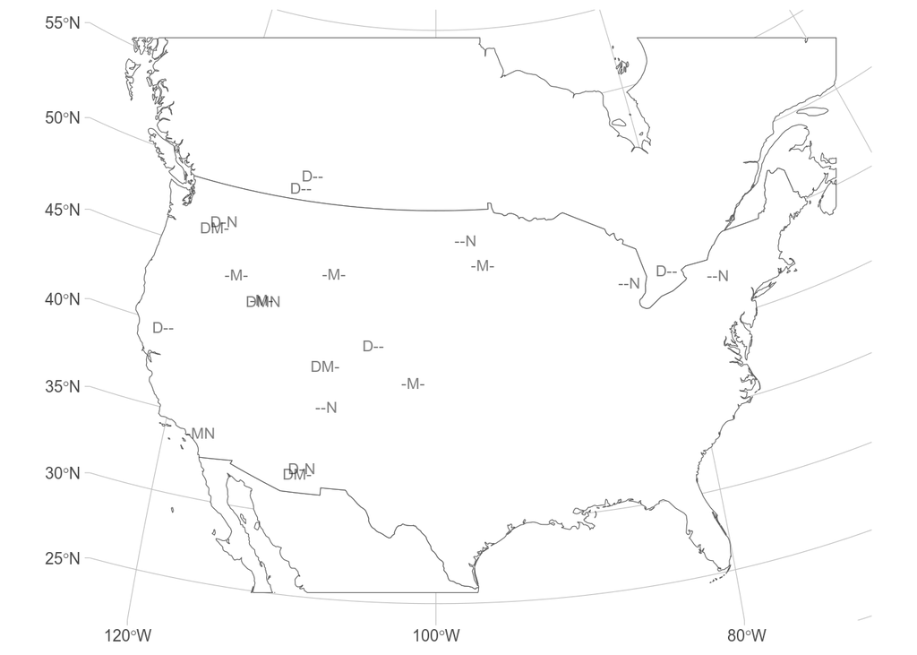

```r
bssp = c(site, 'Location') %>%
  paste(collapse='+') %>%
  paste(popn, sep='~') %>%
  formula %>%
  dcast(data=bs_plot, ., value.var='plotval') %>%
  na.omit

for (i in race) {
  bssp[, i] %<>% {.==1} %>%
    sapply(ifelse, substr(i, 1, 1), '-')
}
bssp$label = apply(bssp[, race], 1, paste, collapse='')
bssp$label %<>% gsub('---', '', .)

bssp = bs_plot[, c(site, 'Location')] %>%
  unique %>%
  merge(bssp[, c(site, 'Location', 'label')], by=c(site, 'Location'))

best_sites_plot = ggplot(basemap) +
  geom_sf(fill='white',
          size=0.2) +
  geom_sf_text(data=bssp,
               aes(label=label),
               size=3,
               alpha=0.5,
               color='black') +
  theme_minimal() +
  labs(fill=expression(paste('Mean Yield [kg ', 'ha'^-1, ']')),
       parse=TRUE,
       x=NULL,
       y=NULL) +
  theme(axis.ticks=element_line(color='gray',
                                size=0.2),
        axis.title=element_text(size=9),
        legend.title=element_text(size=9),
        panel.grid=element_line(color='gray',
                                size=0.2),
        legend.position='bottom')
best_sites_plot
```

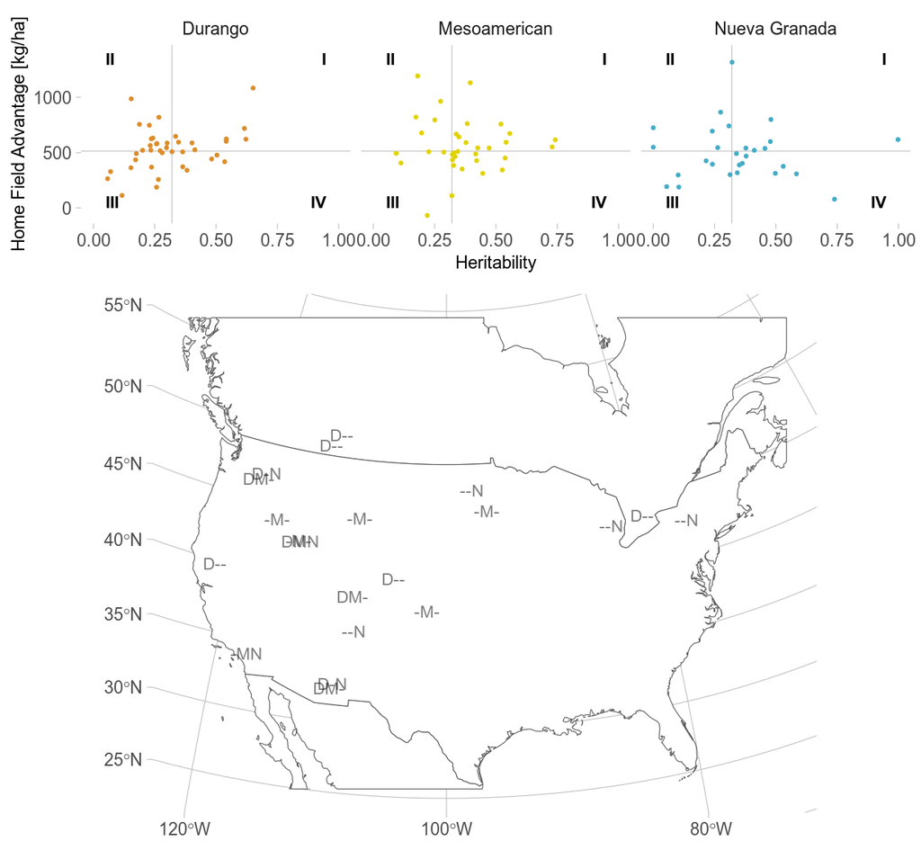

```r
grid.arrange(grobs=list(site_hfa_plot,
                        best_sites_plot),
             heights=c(1,2))
```

### Export Figure 4

```r
if (export) {
  out = "Figure 4 - HFA vs H2.jpg" %>%
    here('results', .)
  jpeg(out,
       width=6.5,
       height=6,
       units='in', res=300)
  grid.arrange(grobs=list(site_hfa_plot,
                          best_sites_plot),
               heights=c(1,2))
  dev.off()

  here(out_dir, 'figure data', 'Fig 4 - HFA vs H2.csv') %>%
    write.csv(site_H_HFA, ., row.names=FALSE)

  here(out_dir, 'figure data', 'Fig 4 - best breeding sites.gpkg') %>%
    st_write(bssp, ., delete_layer=export)
}
```

```
## Deleting layer `Fig 4 - best breeding sites' using driver `GPKG'
## Writing layer `Fig 4 - best breeding sites' to data source `/home/patrick/Cloud/Side Projects/cdbn-home-away/results/figure data/Fig 4 - best breeding sites.gpkg' using driver `GPKG'
## Writing 44 features with 3 fields and geometry type Point.
```

## Fig S3 - faceted best breeding sites, with site names.

Plot best sites on separate maps, labelled by location name

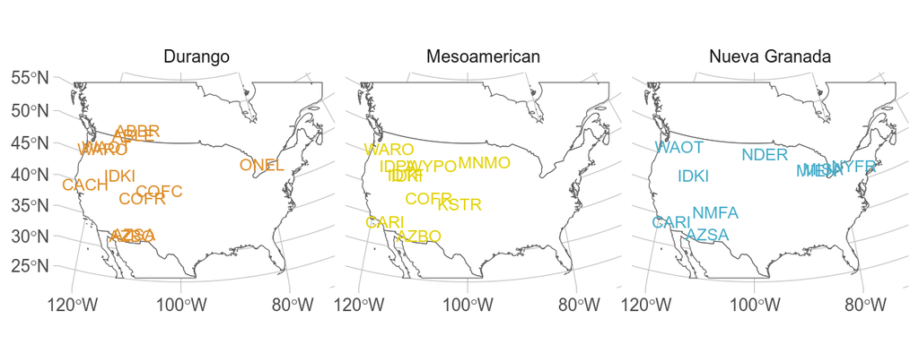

```r
bs_plot$label = apply(bs_plot, 1, function(x) ifelse(x['plotval']==1, x[site], ''))

best_sites_facet_plot = ggplot(basemap) +
  facet_wrap(paste('~', popn) %>% formula,
             nrow=1) +
  scale_color_manual(values=colors, guide=NULL) +
  geom_sf(fill='white',
          size=0.2) +
  geom_sf_text(data=bs_plot,
               aes_string(label='label',
                          color=popn),
               size=3) +
  theme_minimal() +
  labs(fill=expression(paste('Mean Yield [kg ', 'ha'^-1, ']')),
       parse=TRUE,
       x=NULL,
       y=NULL) +
  theme(axis.ticks=element_line(color='gray',
                                size=0.2),
        axis.title=element_text(size=9),
        legend.title=element_text(size=9),
        panel.grid=element_line(color='gray',
                                size=0.2),
        legend.position='bottom')
best_sites_facet_plot
```

### Export Figure S3

```r
if (export) {
 out = "Figure S3 - Best Breeding Sites by Race.jpg" %>%
    here('results', .)
  jpeg(out,
       width=6.5,
       height=2.5,
       units='in', res=300)
  grid.arrange(best_sites_facet_plot)
  dev.off()

  here(out_dir, 'figure data', 'Fig S3 - faceted best breeding sites.gpkg') %>%
    st_write(bs_plot, ., delete_layer=export)
}
```

```
## Deleting layer `Fig S3 - faceted best breeding sites' using driver `GPKG'
## Writing layer `Fig S3 - faceted best breeding sites' to data source `/home/patrick/Cloud/Side Projects/cdbn-home-away/results/figure data/Fig S3 - faceted best breeding sites.gpkg' using driver `GPKG'
## Writing 136 features with 6 fields and geometry type Point.
```